# DATA-413/613 Homework 05 API Data

Author

Te-Jou Hou(Carol)

# 1 Using the Smithsonian API

The Smithsonian has an [Open Access API](https://www.si.edu/openaccess/devtools) for searching its catalog with [API documentation](https://edan.si.edu/openaccess/apidocs/).

- The API returns deeply-nested lists given the complex structure of the data.
- If of interest, more detailed information can be found at [Smithsonian Institution Enterprise Data Access Network + Open Access Initiative Content Repository](https://edan.si.edu/openaccess/docs/).

**Use the {tidyverse}, {keyring}, {httr2}, and {jsonlite} packages for this question.**

```r
library(tidyverse)
library(keyring)
library(httr2)
library(jsonlite)
```

## 1.1 API Key

The API requires an API key available from [data.gov](https://api.data.gov/signup/).

1. Obtain an API key and use a {keyring} function in the console to save it in your credential manager with the name “API_KEY_DATA-GOV”.

## 1.2 General Search Query

1. Create a request object `search_req` for the general “search” query endpoint with URL “https://api.si.edu/openaccess/api/v1.0/search”.

```r
my_url <- "https://api.si.edu/openaccess/api/v1.0/search"
search_req <- request(my_url)
```

2. Review the [API documentation for “search”](https://edan.si.edu/openaccess/apidocs/#api-search-search) and use the `search_req` object to create a query for the phrase “artificial intelligence”.
   - You will need to add your API key to the query.
   - Perform the query and save to an object with the name `search_resp`.

```r
search_req |>
  req_url_query(q = "artificial intelligence") |>
  req_url_query(api_key = keyring::key_get("API_KEY_DATA-GOV")) |>
  req_perform() ->
  search_resp
```

3. Check the status of the query response. It should be 200.

```r
resp_status(search_resp)
```

```
[1] 200
```

## 1.3 Convert to a Tibble with Columns of Interest

1. Convert the body of the `search_resp` object from RAW format to JSON and examine the elements of the response.
- The content of interest is in the `response$rows` elements.
- Save the JSON output from `response$rows` to a variable called `resp_list`. It should have 10 elements.
- Convert `resp_list` to a tibble called `resp_df`.
- It should have 10 rows with one column.

```r
search_resp |>
  resp_body_json() |>
  pluck(3, "rows") ->
  resp_list
length(resp_list)
```

```
[1] 10
```

```r
resp_df <- tibble(resp_list)
resp_df
```

```
# A tibble: 10 × 1
   resp_list
   <list>
 1 <named list [11]>
 2 <named list [11]>
 3 <named list [11]>
 4 <named list [11]>
 5 <named list [11]>
 6 <named list [11]>
 7 <named list [11]>
 8 <named list [11]>
 9 <named list [11]>
10 <named list [11]>
```

2. Use `hoist` to extract the `id` and `title` and `content` from the `resp_df$resp_list` column into columns with those names and save to a tibble called `ids_df`.

```r
resp_df |>
  hoist(.col = resp_list,
        id = "id",
        title = "title",
        content = "content")->
  ids_df
ids_df
```

```
# A tibble: 10 × 4
   id                                title             content      resp_list
   <chr>                             <chr>             <list>       <list>
 1 ld1-1646149545906-1646149878386-1 Building artific… <named list> <named list>
 2 ld1-1646149545906-1646149722751-2 Artificial intel… <named list> <named list>
 3 ld1-1646149545906-1646150096684-2 The Artificial i… <named list> <named list>
 4 ld1-1646149545906-1646149621139-1 AI in the wild s… <named list> <named list>
 5 ld1-1646149545906-1646150082904-2 Artificial intel… <named list> <named list>
 6 ld1-1646149545906-1646149596755-1 Artificial intel… <named list> <named list>
 7 ld1-1646149545906-1646150426847-1 Dictionary of ar… <named list> <named list>
 8 ld1-1646149545906-1646150788587-0 Introduction to … <named list> <named list>
 9 ld1-1646149545906-1646149900795-2 Artificial intel… <named list> <named list>
10 ld1-1646149545906-1646150309912-2 Artificial intel… <named list> <named list>
```

3. Use `hoist()` to extract the element with the URL that is nested inside the `content$descriptiveNonRepeating` element and save the `ids_df`.

```r
ids_df |>
  hoist(content, link = c("descriptiveNonRepeating", "record_link"))->
  ids_df
ids_df
```

```
# A tibble: 10 × 5
   id                                title       link  content      resp_list
   <chr>                             <chr>       <chr> <list>       <list>
 1 ld1-1646149545906-1646149878386-1 Building a… http… <named list> <named list>
 2 ld1-1646149545906-1646149722751-2 Artificial… http… <named list> <named list>
 3 ld1-1646149545906-1646150096684-2 The Artifi… http… <named list> <named list>
 4 ld1-1646149545906-1646149621139-1 AI in the … http… <named list> <named list>
 5 ld1-1646149545906-1646150082904-2 Artificial… http… <named list> <named list>
 6 ld1-1646149545906-1646149596755-1 Artificial… http… <named list> <named list>
 7 ld1-1646149545906-1646150426847-1 Dictionary… http… <named list> <named list>
 8 ld1-1646149545906-1646150788587-0 Introducti… http… <named list> <named list>
 9 ld1-1646149545906-1646149900795-2 Artificial… http… <named list> <named list>
10 ld1-1646149545906-1646150309912-2 Artificial… http… <named list> <named list>
```

4. Use `hoist()` to extract the `object_type` element that is nested inside the `content$indexStructured` element and save the `ids_df`.

```r
ids_df |>
  hoist(content, object_type = c("indexedStructured", "object_type")) ->
  ids_df
ids_df
```

```
# A tibble: 10 × 6
   id                          title link  object_type content      resp_list
   <chr>                       <chr> <chr> <list>      <list>       <list>
 1 ld1-1646149545906-16461498… Buil… http… <list [4]>  <named list> <named list>
 2 ld1-1646149545906-16461497… Arti… http… <list [3]>  <named list> <named list>
 3 ld1-1646149545906-16461500… The … http… <list [1]>  <named list> <named list>
 4 ld1-1646149545906-16461496… AI i… http… <list [2]>  <named list> <named list>
 5 ld1-1646149545906-16461500… Arti… http… <list [2]>  <named list> <named list>
 6 ld1-1646149545906-16461495… Arti… http… <list [1]>  <named list> <named list>
 7 ld1-1646149545906-16461504… Dict… http… <list [2]>  <named list> <named list>
 8 ld1-1646149545906-16461507… Intr… http… <list [1]>  <named list> <named list>
 9 ld1-1646149545906-16461499… Arti… http… <list [1]>  <named list> <named list>
10 ld1-1646149545906-16461503… Arti… http… <list [1]>  <named list> <named list>
```

5. It is a list column. Why?

Because each element in `object_type` has a different length, for example, the first element contains 4 characters, the second element contains 3 characters, and the third element contains only 1 character, using a list allows for flexible storage of these variable-length data. Therefore, `object_type` is a list column.

6. Unnest the `object_type` column so the tibble has nine variables and 10 rows and save as `ids_dfw`.

```r
ids_df |>
  unnest_wider(object_type, names_sep = "-") ->
  ids_dfw
ids_dfw
```

```
# A tibble: 10 × 9
   id                title link  `object_type-1` `object_type-2` `object_type-3`
   <chr>             <chr> <chr> <chr>           <chr>           <chr>
 1 ld1-164614954590… Buil… http… Computers / In… Documents d'in… Books
 2 ld1-164614954590… Arti… http… Scientific ill… Pictorial works Popular Work
 3 ld1-164614954590… The … http… Books           <NA>            <NA>
 4 ld1-164614954590… AI i… http… E-books         Electronic inf… <NA>
 5 ld1-164614954590… Arti… http… Dictionaries    Books           <NA>
 6 ld1-164614954590… Arti… http… Books           <NA>            <NA>
 7 ld1-164614954590… Dict… http… Dictionaries    Books           <NA>
 8 ld1-164614954590… Intr… http… Books           <NA>            <NA>
 9 ld1-164614954590… Arti… http… Books           <NA>            <NA>
10 ld1-164614954590… Arti… http… Books           <NA>            <NA>
# ℹ 3 more variables: `object_type-4` <chr>, content <list>, resp_list <list>
```

## 1.4 Smithsonian Object Types

1. Use code to show the distinct object types there are across all object columns.
- Hint: consider using a `tidyr::tidyr_tidy_select()` helper function to select just those columns and then pivot.

```r
ids_dfw |>
  select(matches("object_type")) |>
  pivot_longer(cols = everything(), values_to = "object_type") |>
  filter(!is.na(object_type)) |>
  distinct(object_type)
```

```
# A tibble: 10 × 1
   object_type
   <chr>
 1 Computers / Intelligence (AI) & Semantics
 2 Documents d'information
 3 Books
 4 Informational works
 5 Scientific illustrations
 6 Pictorial works
 7 Popular Work
 8 E-books
 9 Electronic information resources
10 Dictionaries
```

## 1.5 Create a Smithsonian Search Function

a.- c. Consider if you combined the code from the above into one code chunk to create a function called `smith_search` with three arguments: `req`, `q`, and `rows` where the output is a tibble similar to what you created above with `ids_df`.

- `req` is a request object for the search URL.
- `q` is the query or search phrase.
- `rows` is the number of rows in the query with a default value of 10.
- Assume all required packages have been loaded and the API key is named “API_KEY_DATA-GOV”.
- There is no need to include documentation or error checking.

The following lines can be used in creating the function, **but they are in the wrong order and five lines are missing.** You will need to rearrange and create the missing lines.

- Note: The code lines use the natural pipe `|>` which has different rules than the magrittr pipe `%>%`.
  - The magrittr pipe allows the use of the pronoun `.` and the natural pipe allows the use of the pronoun `_`.
  - However, the natural pipe requires its pronoun be used with a named argument.
  - It also requires the left side of the pipe be a completed object before using the `$` operator so it may require enclosing the left side (several steps) within parentheses.
  - That is why you see “perhaps unusual” left or right parentheses in some of the lines below.

```
hoist(content, link = c("descriptiveNonRepeating", "record_link")) |>
req_url_query(q = q) |>
  .col = data,
resp_body_json(resp = _))$response$rows |>
(req |>
   title = "title",
tibble(data = _) |>
hoist(
  id = "id",
) |>
req_url_query(api_key = keyring::key_get("API_KEY_DATA-GOV")) |>
unnest_wider(object_type, names_sep = "-")
  content = "content"
```

```r
smith_search <- function(req, q, rows = 10) {

  (req |>
     req_url_query(q = q) |>
     req_url_query(api_key = keyring::key_get("API_KEY_DATA-GOV")) |>
     req_url_query(rows = rows) |>
     req_perform() |>
     resp_body_json(resp = _))$response$rows |>
    tibble(data = _) |>
    hoist(
      .col = data,
      id = "id",
      title = "title",
      content = "content"
    ) |>
    hoist(content, link = c("descriptiveNonRepeating", "record_link")) |>
    hoist(content, object_type = c("indexedStructured", "object_type")) |>
    unnest_wider(object_type, names_sep = "-")
}
```

4. Run your function with the arguments `search_req` and search phrase “artificial intelligence” and assign the output to `ids_test`.
- Use `identical()` to confirm `ids_test` is identical to `ids_dfw` for all rows of all columns except the last, without using the column number so it will work if the number of columns changes for different query phrases.

```r
search_req<- request("https://api.si.edu/openaccess/api/v1.0/search")
ids_test <- smith_search(search_req, "artificial intelligence")

identical(
  ids_test[, -ncol(ids_test)],
  ids_dfw[, -ncol(ids_dfw)]
)
```

```
[1] TRUE
```

5. Run your function with the arguments `search_req`, the search phrase “artificial intelligence”, and `rows = 20` and assign the output to `ids_more`.

```r
ids_more <- smith_search(search_req, "artificial intelligence", 20)
ids_more
```

```
# A tibble: 20 × 9
   id                title link  `object_type-1` `object_type-2` `object_type-3`
   <chr>             <chr> <chr> <chr>           <chr>           <chr>
 1 ld1-164614954590… "Bui… http… Computers / In… Documents d'in… Books
 2 ld1-164614954590… "Art… http… Scientific ill… Pictorial works Popular Work
 3 ld1-164614954590… "The… http… Books           <NA>            <NA>
 4 ld1-164614954590… "AI … http… E-books         Electronic inf… <NA>
 5 ld1-164614954590… "Art… http… Dictionaries    Books           <NA>
 6 ld1-164614954590… "Art… http… Books           <NA>            <NA>
 7 ld1-164614954590… "Dic… http… Dictionaries    Books           <NA>
 8 ld1-164614954590… "Int… http… Books           <NA>            <NA>
 9 ld1-164614954590… "Art… http… Books           <NA>            <NA>
10 ld1-164614954590… "Art… http… Books           <NA>            <NA>
11 ld1-164614954590… "Thi… http… Books           <NA>            <NA>
12 ld1-164614954590… "Art… http… Books           <NA>            <NA>
13 ld1-164614954590… "An … http… Books           <NA>            <NA>
14 ld1-164614954590… "AI … http… Books           <NA>            <NA>
15 ld1-164614954590… "The… http… Books           <NA>            <NA>
16 ld1-164614954590… "Art… http… Books           <NA>            <NA>
17 ld1-164614954590… "The… http… Books           <NA>            <NA>
18 ld1-164614954590… "Art… http… Books           <NA>            <NA>
19 ld1-164614954590… "Sel… http… Books           <NA>            <NA>
20 ld1-164614954590… "Thi… http… Books           <NA>            <NA>
# ℹ 3 more variables: `object_type-4` <chr>, content <list>, data <list>
```

```r
ids_more |>
  select(matches("object_type")) |>
  pivot_longer(cols = everything(), values_to = "object_type") |>
  filter(!is.na(object_type)) |>
  distinct(object_type) |>
  mutate(object_type = str_to_title(object_type)) |>
  arrange(object_type) |>
  as_tibble()
```

```
# A tibble: 10 × 1
   object_type
   <chr>
 1 Books
 2 Computers / Intelligence (Ai) & Semantics
 3 Dictionaries
 4 Documents D'information
 5 E-Books
 6 Electronic Information Resources
 7 Informational Works
 8 Pictorial Works
 9 Popular Work
10 Scientific Illustrations
```

## 1.6 Searching Titles (Extra Credit)

Create and show a tibble with the following three columns:

- `words` is the output of using your function to query titles with the words “data science” with 20 rows and extracting just the titles.
- `words_single` is the output of using your function to query the titles with the phrase ‘data science’ inside the query with 20 rows and extracting just the titles.
- `words_double` is the output of using your function to query the titles with the phrase “data science” inside the query with 20 rows and extracting just the titles.
  - Hint: you will need to use a combination of ’ and ” to create a valid query with embedded phrases.
- Use {stringr} to select just the first 30 characters of each title.
- What do you observe?

```r
words <- smith_search(search_req, "data science", 20) |>
  pull(title) |>
  str_sub(1, 30)

words_single <- smith_search(search_req, "'data science'", 20) |>
  pull(title) |>
  str_sub(1, 30)

words_double <- smith_search(search_req, "\"data science\"", 20) |>
  pull(title) |>
  str_sub(1, 30)

tibble(
  words = words,
  words_single = words_single,
  words_double = words_double
)
```

```
# A tibble: 20 × 3
   words                            words_single                    words_double
   <chr>                            <chr>                           <chr>
 1 "Mohawk Data Sciences Backgroun" "Mohawk Data Sciences Backgrou… "Mohawk Dat…
 2 "Mohawk Data Sciences Corp Annu" "Mohawk Data Sciences Corp Ann… "Mohawk Dat…
 3 "Mohawk Data Sciences Corp Annu" "Mohawk Data Sciences Corp Ann… "Mohawk Dat…
 4 "Mohawk Data Sciences Corp. Fir" "Mohawk Data Sciences Corp. Fi… "Mohawk Dat…
 5 "Data feminism Catherine D'Igna" "Data feminism Catherine D'Ign… "Reprint of…
 6 "Reprint of Mohawk Data Science" "Reprint of Mohawk Data Scienc… "Data femin…
 7 "Series 21 General Description"  "Series 21 General Description" "Series 21 …
 8 "Tape Reel from MDS 1101"        "Tape Reel from MDS 1101"       "[Trade cat…
 9 "Mohawk Data: From $5 to $160"   "Mohawk Data: From $5 to $160"  "Mohawk Dat…
10 "[Trade catalogs from Mohawk Da" "[Trade catalogs from Mohawk D… "Tape Reel …
11 "An introduction to data scienc" "An introduction to data scien… "An introdu…
12 "Press Release - MDS Executive " "Press Release - MDS Executive… "Press Rele…
13 "Advertisement - MDS 3600 Contr" "Advertisement - MDS 3600 Cont… "Advertisem…
14 "2400 Key-Display System Genera" "2400 Key-Display System Gener… "2400 Key-D…
15 "Solving Input Problems"         "Solving Input Problems"        "Solving In…
16 "Study shows mag tape recorders" "Study shows mag tape recorder… "Study show…
17 "1101 Keyed Data-Recorder Adver" "1101 Keyed Data-Recorder Adve… "Sheet, MDS…
18 "MDS 1103 Data Recorder Referen" "MDS 1103 Data Recorder Refere… "1101 Keyed…
19 "Data recorders keep Firestone " "Data recorders keep Firestone… "MDS 1103 D…
20 "Sheet, MDS Fact Sheet"          "Sheet, MDS Fact Sheet"         "Data recor…
```

The results of words and words_single are exactly the same, while words_double, although the order differs slightly, contains the same content as well.

# 2 Using an API of your choice

1. Pick a website of your choice (not discussed in class) that requires a free API key and has recent data. You may use an R package for the website or use {httr2} to interact directly with the API.
2. **Identify the link to instructions to obtain a key for the API.**
3. Use your API with {keyring} to download a data set with multiple variables. **Do not include your key in your file.**
4. Convert elements of interest into a tibble
5. State a question of interest.
6. Create an appropriate plot with proper labels and theme to analyze your question of interest.
7. Interpret the plot to answer your question.
8. Read the site guidance for use of their data, e.g., terms and conditions, API documentation, or FAQ (if they exist)) and, in a few sentences, comment on the severity or strictness of the guidance or the lack of guidance. Discuss how the guidance could enable or restrain unethical uses of the data.

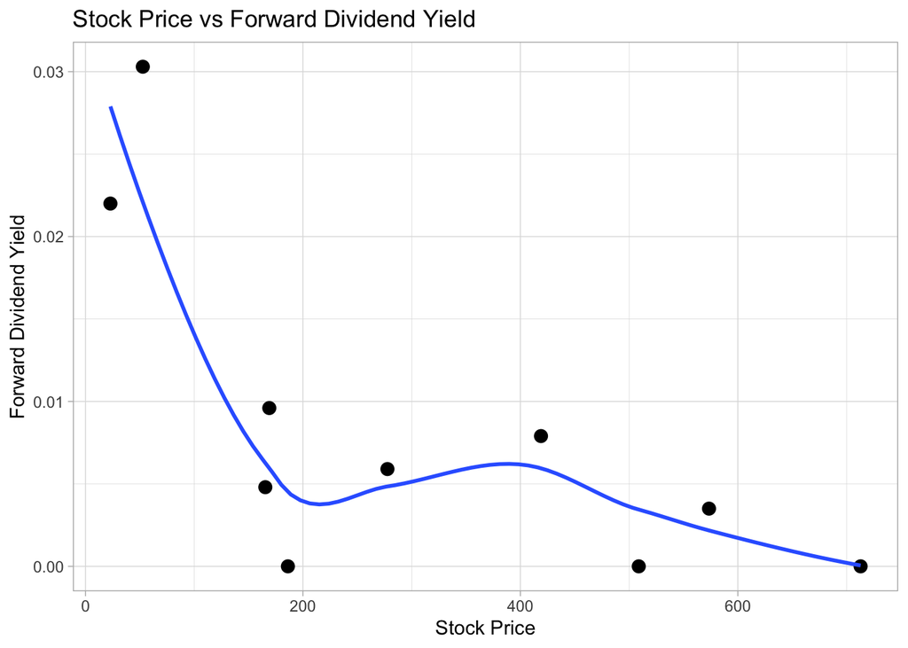

```r
# The website that I choice: https://aletheiaapi.com/docs/#crypto-quote

aletheia_search <- function(symbol) {

  request("https://api.aletheiaapi.com/StockData") |>
     req_url_query(key = keyring::key_get("API_KEY_ALETHEIA")) |>
     req_url_query(Symbol = symbol) |>
     req_url_query(`Accept-Version` = 2) |>
     req_perform() |>
     resp_body_json() |>
     as_tibble()
}

symbols <- c("GOOGL", "MSFT", "META", "AMZN", "NFLX", "INTC", "CSCO", "ORCL",
             "ADBE", "CRM")

map(symbols, aletheia_search)|>
  bind_rows() ->
  data_aletheia

ggplot(data_aletheia, aes(x = Price, y = ForwardDividendYield)) +
  geom_point(size = 3) +
  geom_smooth(se = FALSE) +
  labs(title = "Stock Price vs Forward Dividend Yield",
       x = "Stock Price",
       y = "Forward Dividend Yield") +
  theme_light()
```

**Question of interest**

I would like to explore whether there is a relationship between the expected dividend yield and stock prices among major companies in fields such as internet services, digital advertising, and software development. The expected dividend yield serves as a measure of the potential dividend income investors can earn from holding a company’s stock. Therefore, I hypothesize that companies with higher expected dividend yields might also have higher stock prices, indicating a positive correlation between the two.

**Answer my question**

From the scatterplot above, we can observe that the relationship between the expected dividend yield and stock price for these companies is not positive but negative. This might be because industries like internet services, digital advertising, and software development are rapidly growing sectors. Companies with higher stock prices tend to be growth-oriented, reinvesting most of their earnings back into the business to fuel expansion. As a result, they often pay lower dividends or none at all, leading to lower expected dividend yields.

On the other hand, companies with lower stock prices may be viewed by investors as having limited future growth potential or higher risks. To attract investors, these companies offer higher dividend yields. Alternatively, it could be that management believes the company lacks effective internal investment opportunities, so they choose to distribute profits to shareholders. This may signal limited future growth prospects, which can also lead to weaker stock performance.

In summary, the negative relationship likely indicates that in this sector, investors prioritize a company’s growth potential over current dividend returns.

**Comment on the site guidance**

The stock-related trading information provided by this website consists of data that is already publicly available. Therefore, even though the website does not clearly specify the conditions and rules for using this data or restrictions against unethical usage, it should not pose significant risks or concerns. However, I believe the site could benefit from implementing usage limitations for the API, such as restricting the number of requests per minute or per day. This would help prevent malicious copying or scraping of the data by others.

Additionally, I find that the API documentation lacks clarity in several areas regarding data usage guidelines. For instance, it could provide more detailed information about the request parameters for each API endpoint, including their types and formats. Furthermore, the documentation should specify the data format returned by the API and include examples of the responses. Describing the various parameters within the responses and their meanings would also assist developers in understanding the returned data. Providing these details would greatly enhance users’ ability to interact with the API and effectively handle the data.